# Loaded Joint Simon Effect

## 3.2 Color Judgment Task

본 연구에서 가장 중요한 분석이다.

참가자간 요인 `Group` (**Low load** vs. **High load**), 참가자내 요인 `Task` (**Single** vs. **Dual**), 참가자내 요인 `Compatibility` (**Compatible** vs. **Incompatible**)의 2x2x2 설계이다.

### 3.2.1 Descriptive Stats

#### 3.2.1.1 Accuracy

```r
TT <- read.csv('data/mergeJSEv5_GNGtask.csv', header = TRUE)
headTail(TT)
##       sid group initblk epoch trial task compatibility targ col dir resp corr
## 1     101   Low       1     1     1    1             1    1   1   1    1    1
## 2     101   Low       1     1     2    1             0    0   2   2    0    1
## 3     101   Low       1     1     3    1             0    0   2   1    0    1
## 4     101   Low       1     1     4    1             0    0   2   1    0    1
## ...   ...  <NA>     ...   ...   ...  ...           ...  ... ... ...  ...  ...
## 30717 232  High       1     4   477    2             0    0   1   2    0    1
## 30718 232  High       1     4   478    2             0    0   1   1    0    1
## 30719 232  High       1     4   479    2             1    1   2   2    1    1
## 30720 232  High       1     4   480    2             0    0   1   1    0    1
##         rt
## 1     0.99
## 2        0
## 3        0
## 4        0
## ...    ...
## 30717    0
## 30718    0
## 30719  0.3
## 30720    0

unique(TT$group)
## [1] "Low"  "High"
unique(TT$epoch)
## [1] 1 2 3 4
unique(TT$task)
## [1] 1 2
unique(TT$compatibility) # 1 0 2
## [1] 1 0 2
unique(TT$targ)
## [1] 1 0
unique(TT$corr)
## [1] 1 0

table(TT$targ, TT$sid)
##
##     101 102 103 104 105 106 107 108 109 110 111 112 113 114 115 116 117 118 119
##   0 240 240 240 240 240 240 240 240 240 240 240 240 240 240 240 240 240 240 240
##   1 240 240 240 240 240 240 240 240 240 240 240 240 240 240 240 240 240 240 240
##
##     120 121 122 123 124 125 126 127 128 129 130 131 132 201 202 203 204 205 206
##   0 240 240 240 240 240 240 240 240 240 240 240 240 240 240 240 240 240 240 240
##   1 240 240 240 240 240 240 240 240 240 240 240 240 240 240 240 240 240 240 240
##
##     207 208 209 210 211 212 213 214 215 216 217 218 219 220 221 222 223 224 225
##   0 240 240 240 240 240 240 240 240 240 240 240 240 240 240 240 240 240 240 240
##   1 240 240 240 240 240 240 240 240 240 240 240 240 240 240 240 240 240 240 240
##
##     226 227 228 229 230 231 232
##   0 240 240 240 240 240 240 240
##   1 240 240 240 240 240 240 240
table(TT$compatibility, TT$sid)
##
##     101 102 103 104 105 106 107 108 109 110 111 112 113 114 115 116 117 118 119
##   0 240 240 240 240 240 240 240 240 240 240 240 240 240 240 240 240 240 240 240
##   1 120 120 120 120 120 120 120 120 120 120 120 120 120 120 120 120 120 120 120
##   2 120 120 120 120 120 120 120 120 120 120 120 120 120 120 120 120 120 120 120
##
##     120 121 122 123 124 125 126 127 128 129 130 131 132 201 202 203 204 205 206
##   0 240 240 240 240 240 240 240 240 240 240 240 240 240 240 240 240 240 240 240
##   1 120 120 120 120 120 120 120 120 120 120 120 120 120 120 120 120 120 120 120
##   2 120 120 120 120 120 120 120 120 120 120 120 120 120 120 120 120 120 120 120
##
##     207 208 209 210 211 212 213 214 215 216 217 218 219 220 221 222 223 224 225
##   0 240 240 240 240 240 240 240 240 240 240 240 240 240 240 240 240 240 240 240
##   1 120 120 120 120 120 120 120 120 120 120 120 120 120 120 120 120 120 120 120
##   2 120 120 120 120 120 120 120 120 120 120 120 120 120 120 120 120 120 120 120
##
##     226 227 228 229 230 231 232
##   0 240 240 240 240 240 240 240
##   1 120 120 120 120 120 120 120
##   2 120 120 120 120 120 120 120


TT <- TT %>% mutate(group = factor(group, levels = c('Low', 'High')),
                    task = factor(task, levels=1:2, labels=c("Single","Dual")),
                    compatibility = factor(compatibility, levels=0:2,
                                           labels=c("Nontarget","Compatible","Incompatible")),
                    targ = factor(targ, levels=0:1, labels=c("Nontarget","Target")),
                    rt = rt*1000) %>%
  filter(targ == "Target") %>%
  droplevels() %>%
  select(sid, group, epoch, task, compatibility, corr, rt)

TT %>% sapply(levels)
## $sid
## NULL
##
## $group
## [1] "Low"  "High"
##
## $epoch
## NULL
##
## $task
## [1] "Single" "Dual"
##
## $compatibility
## [1] "Compatible"   "Incompatible"
##
## $corr
## NULL
##
## $rt
## NULL

headTail(TT)
##       sid group epoch   task compatibility corr     rt
## 1     101   Low     1 Single    Compatible    1 988.24
## 2     101   Low     1 Single  Incompatible    1 326.42
## 3     101   Low     1 Single    Compatible    1 311.76
## 4     101   Low     1 Single  Incompatible    1 268.35
## ...   ...  <NA>   ...   <NA>          <NA>  ...    ...
## 15357 232  High     4   Dual    Compatible    1 269.62
## 15358 232  High     4   Dual  Incompatible    1 289.87
## 15359 232  High     4   Dual    Compatible    1  274.2
## 15360 232  High     4   Dual    Compatible    1 299.84

unique(TT$compatibility)
## [1] Compatible   Incompatible
## Levels: Compatible Incompatible

# averaged accuracy
aTTslong <- TT %>% group_by(group, sid, task, compatibility) %>%
  summarise(Accuracy = mean(corr)*100) %>%
  ungroup()

# summary
aTTsum <- aTTslong %>% group_by(group, task, compatibility) %>%
  summarise(N = n(),
                    MN = mean(Accuracy),
            SD = sd(Accuracy)) %>%
  ungroup()
aTTsum %>%
  kable(digits = 4, caption = "Descriptive statistics: Group x Load x Congruency")
```

Descriptive statistics: Group x Load x Congruency

| group | task | compatibility | N | MN | SD |
| --- | --- | --- | --- | --- | --- |
| Low | Single | Compatible | 32 | 97.1354 | 4.9047 |
| Low | Single | Incompatible | 32 | 96.7708 | 4.8810 |
| Low | Dual | Compatible | 32 | 97.6042 | 3.8085 |
| Low | Dual | Incompatible | 32 | 96.7188 | 4.7798 |
| High | Single | Compatible | 32 | 98.2292 | 3.6890 |
| High | Single | Incompatible | 32 | 97.0833 | 3.9937 |
| High | Dual | Compatible | 32 | 97.1354 | 5.9904 |
| High | Dual | Incompatible | 32 | 97.4479 | 5.2017 |

```r
aTTslong %>% group_by(group) %>%
  summarise(MN = mean(Accuracy),
            SD = sd(Accuracy)) %>%
  ungroup() %>%
  kable(digits = 4, caption = "Descriptive statistics: Group")
```

Descriptive statistics: Group

| group | MN | SD |
| --- | --- | --- |
| Low | 97.0573 | 4.5750 |
| High | 97.4740 | 4.7739 |

```r
aTTslong %>% group_by(task) %>%
  summarise(MN = mean(Accuracy),
            SD = sd(Accuracy)) %>%
  ungroup() %>%
  kable(digits = 4, caption = "Descriptive statistics: Load")
```

Descriptive statistics: Load

| task | MN | SD |
| --- | --- | --- |
| Single | 97.3047 | 4.3828 |
| Dual | 97.2266 | 4.9595 |

```r
aTTslong %>% group_by(compatibility) %>%
  summarise(MN = mean(Accuracy),
            SD = sd(Accuracy)) %>%
  ungroup() %>%
  kable(digits = 4, caption = "Descriptive statistics: Congruency")
```

Descriptive statistics: Congruency

| compatibility | MN | SD |
| --- | --- | --- |
| Compatible | 97.5260 | 4.6580 |
| Incompatible | 97.0052 | 4.6878 |

#### 3.2.1.2 RT

```r
( num_anticip <- nrow(TT %>% filter(corr==1 & rt < 150)) ) # anticipatory response 제거
## [1] 4

cTT <- TT %>% filter(corr==1 & rt >= 150) # 정반응만 선별

num_anticip*100/nrow(cTT) # 0.02678093%
## [1] 0.02678093

headTail(cTT)
##       sid group epoch   task compatibility corr     rt
## 1     101   Low     1 Single    Compatible    1 988.24
## 2     101   Low     1 Single  Incompatible    1 326.42
## 3     101   Low     1 Single    Compatible    1 311.76
## 4     101   Low     1 Single  Incompatible    1 268.35
## ...   ...  <NA>   ...   <NA>          <NA>  ...    ...
## 14933 232  High     4   Dual    Compatible    1 269.62
## 14934 232  High     4   Dual  Incompatible    1 289.87
## 14935 232  High     4   Dual    Compatible    1  274.2
## 14936 232  High     4   Dual    Compatible    1 299.84

# trimmed
tTT <- cTT %>% group_by(group, sid, task, compatibility) %>%
  nest() %>%
  mutate(lbound = map(data, ~mean(.$rt)-3*sd(.$rt)), # lower/upper bound 계산
         ubound = map(data, ~mean(.$rt)+3*sd(.$rt))) %>%
  unnest(c(lbound, ubound)) %>%
  unnest(data) %>%
  mutate(outlier = (rt < lbound)|(rt > ubound)) %>%
  filter(outlier == FALSE) %>%
  select(group, sid, epoch, task, compatibility, rt)

(nrow(cTT)-nrow(tTT))*100/nrow(cTT) # 1.131494% 제거되었다.
## [1] 1.131494

tTTslong <- tTT %>% group_by(group, sid, task, compatibility) %>%
  summarise(RT = mean(rt)) %>%
  ungroup()

# summary
tTTsum <- tTTslong %>% group_by(group, task, compatibility) %>%
  summarise(MN = mean(RT),
            SD = sd(RT)) %>%
  ungroup()
tTTsum %>%
  kable(digits = 4, caption = "Descriptive statistics: Group x Task x Compatibility")
```

Descriptive statistics: Group x Task x Compatibility

| group | task | compatibility | MN | SD |
| --- | --- | --- | --- | --- |
| Low | Single | Compatible | 355.8836 | 26.2698 |
| Low | Single | Incompatible | 362.0058 | 29.0895 |
| Low | Dual | Compatible | 361.8038 | 26.5217 |
| Low | Dual | Incompatible | 366.3566 | 27.9480 |
| High | Single | Compatible | 354.2354 | 33.5891 |
| High | Single | Incompatible | 354.9457 | 34.3319 |
| High | Dual | Compatible | 359.3876 | 38.6664 |
| High | Dual | Incompatible | 360.8769 | 40.1932 |

```r
tTTslong %>% group_by(group) %>%
  summarise(MN = mean(RT),
            SD = sd(RT)) %>%
  ungroup() %>%
  kable(digits = 4, caption = "Descriptive statistics: Group")
```

Descriptive statistics: Group

| group | MN | SD |
| --- | --- | --- |
| Low | 361.5125 | 27.4105 |
| High | 357.3614 | 36.4755 |

```r
tTTslong %>% group_by(task) %>%
  summarise(MN = mean(RT),
            SD = sd(RT)) %>%
  ungroup() %>%
  kable(digits = 4, caption = "Descriptive statistics: Task")
```

Descriptive statistics: Task

| task | MN | SD |
| --- | --- | --- |
| Single | 356.7677 | 30.7842 |
| Dual | 362.1062 | 33.5924 |

```r
tTTslong %>% group_by(compatibility) %>%
  summarise(MN = mean(RT),
            SD = sd(RT)) %>%
  ungroup() %>%
  kable(digits = 4, caption = "Descriptive statistics: Compatibility")
```

Descriptive statistics: Compatibility

| compatibility | MN | SD |
| --- | --- | --- |
| Compatible | 357.8276 | 31.4529 |
| Incompatible | 361.0463 | 33.1055 |

반응시간이 150ms보다 빠른 4시행( 0.0268%)을 분석에서 제외한 후, 각 참가자의 조건별 반응시간들 중 평균으로부터 3*SD*를 벗어난 1.1315%의 반응시간들을 분석에서 추가로 제외하였다.

### 3.2.2 Plot

#### 3.2.2.1 Accuracy

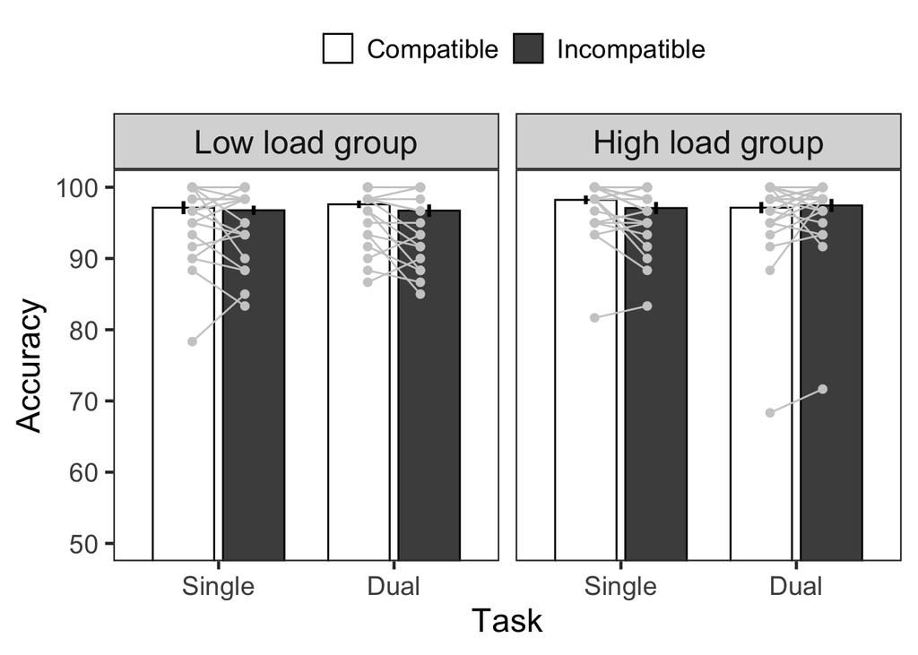

```r
aTTswide <- aTTslong %>% pivot_wider(id_cols=c('group', 'sid'),
                                     names_from=c('task', 'compatibility'),
                                     values_from='Accuracy' )
aTTswideL <- aTTswide %>% filter(group == 'Low')
aTTswideH <- aTTswide %>% filter(group == 'High')

aTTmean <- aTTslong %>%
  group_by(group, task, compatibility) %>%
  summarise(Accuracy = mean(Accuracy)) %>%
  ungroup()

tmp1 <- aTTslong %>% filter(group == "Low") %>%
  wsci(id = "sid",
       factor = c("task", "compatibility"),
       dv = "Accuracy") %>%
  mutate(group = "Low") %>%
  select(group, task, compatibility, Accuracy) %>%
  rename("wsci" = "Accuracy")

tmp2 <- aTTslong %>% filter(group == "High") %>%
  wsci(id = "sid",
       factor = c("task", "compatibility"),
       dv = "Accuracy") %>%
  mutate(group = "High") %>%
  select(group, task, compatibility, Accuracy) %>%
  rename("wsci" = "Accuracy")

aTTwsci <- merge(tmp1, tmp2, all = TRUE)

aTTg <- merge(aTTmean, aTTwsci, by = c("group", "task", "compatibility"), all = TRUE)

group.labs <- c("Low load group", "High load group")
names(group.labs) <- c("Low", "High")

ggplot() +
  geom_bar(data=aTTg, aes(x=task, y=Accuracy, fill=compatibility),
           stat="identity", width=0.7, color="black", position=position_dodge(.8)) +
  facet_wrap(~group, labeller = labeller(group = group.labs)) +
  geom_linerange(data=aTTg, aes(x=task, ymin=Accuracy-wsci, ymax=Accuracy+wsci,
                                group=compatibility),
                 size=1, position=position_dodge(0.8)) +
  scale_fill_manual(values=c('gray100','gray30'),
                    labels=c("Compatible", "Incompatible")) +
  # scale_fill_manual(values=c('#0073C2FF','#EFC000FF'),
  #                   labels=c("Compatible", "Incompatible")) +
  geom_point(data=aTTslong, aes(x=task, y=Accuracy, group=compatibility),
             position=position_dodge(0.6), color="gray80", size=1.8) +
  geom_segment(data=aTTswideL, aes(x=1-.15, y=Single_Compatible,
                                   xend=1+.15, yend=Single_Incompatible), color="gray80") +
  geom_segment(data=aTTswideL, aes(x=2-.15, y=Dual_Compatible,
                                   xend=2+.15, yend=Dual_Incompatible), color="gray80") +
  geom_segment(data=aTTswideH, aes(x=1-.15, y=Single_Compatible,
                                   xend=1+.15, yend=Single_Incompatible), color="gray80") +
  geom_segment(data=aTTswideH, aes(x=2-.15, y=Dual_Compatible,
                                   xend=2+.15, yend=Dual_Incompatible), color="gray80") +
  labs(x = "Task", y = "Accuracy") +
  coord_cartesian(ylim = c(50, 100), clip = "on") +
  theme_bw(base_size = 18) +
  theme(legend.position="top",
        legend.spacing.x = unit(0.5, 'lines'),
        strip.text.x = element_text(size = 18),
        legend.title = element_blank(),
        legend.background = element_blank(),
        panel.grid.major = element_blank(),
        panel.grid.minor = element_blank())
```

#### 3.2.2.2 RT

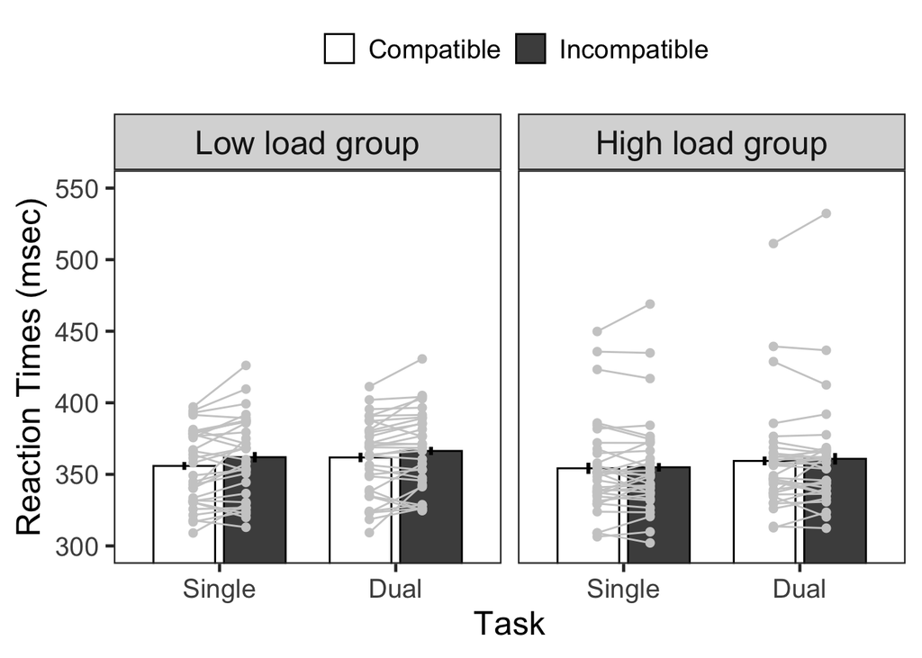

```r
tTTswide <- tTTslong %>% pivot_wider(id_cols=c('group', 'sid'),
                                     names_from=c('task', 'compatibility'),
                                     values_from='RT' )
tTTswideL <- tTTswide %>% filter(group == 'Low')
tTTswideH <- tTTswide %>% filter(group == 'High')

tTTmean <- tTTslong %>%
  group_by(group, task, compatibility) %>%
  summarise(RT = mean(RT)) %>%
  ungroup()

tmp1 <- tTTslong %>% filter(group == "Low") %>%
  wsci(id = "sid",
       factor = c("task", "compatibility"),
       dv = "RT") %>%
  mutate(group = "Low") %>%
  select(group, task, compatibility, RT) %>%
  rename("wsci" = "RT")

tmp2 <- tTTslong %>% filter(group == "High") %>%
  wsci(id = "sid",
       factor = c("task", "compatibility"),
       dv = "RT") %>%
  mutate(group = "High") %>%
  select(group, task, compatibility, RT) %>%
  rename("wsci" = "RT")

tTTwsci <- merge(tmp1, tmp2, all = TRUE)

tTTg <- merge(tTTmean, tTTwsci, by = c("group", "task", "compatibility"), all = TRUE)

group.labs <- c("Low load group", "High load group")
names(group.labs) <- c("Low", "High")

# range(tTTslong$RT)

ggplot() +
  geom_bar(data=tTTg, aes(x=task, y=RT, fill=compatibility),
           stat="identity", width=0.7, color="black", position=position_dodge(.8)) +
  facet_wrap(~group, labeller = labeller(group = group.labs)) +
  geom_linerange(data=tTTg, aes(x=task, ymin=RT-wsci, ymax=RT+wsci, group=compatibility),
                 size=1, position=position_dodge(0.8)) +
  scale_fill_manual(values=c('gray100','gray30'),
                    labels=c("Compatible", "Incompatible")) +
  # scale_fill_manual(values=c('#0073C2FF','#EFC000FF'),
  #                   labels=c("Compatible", "Incompatible")) +
  geom_point(data=tTTslong, aes(x=task, y=RT, group=compatibility),
             position=position_dodge(0.6), color="gray80", size=1.8) +
  geom_segment(data=tTTswideL, aes(x=1-.15, y=Single_Compatible,
                                   xend=1+.15, yend=Single_Incompatible), color="gray80") +
  geom_segment(data=tTTswideL, aes(x=2-.15, y=Dual_Compatible,
                                   xend=2+.15, yend=Dual_Incompatible), color="gray80") +
  geom_segment(data=tTTswideH, aes(x=1-.15, y=Single_Compatible,
                                   xend=1+.15, yend=Single_Incompatible), color="gray80") +
  geom_segment(data=tTTswideH, aes(x=2-.15, y=Dual_Compatible,
                                   xend=2+.15, yend=Dual_Incompatible), color="gray80") +
  labs(x = "Task", y = "Reaction Times (msec)") +
  coord_cartesian(ylim = c(300, 550), clip = "on") +
  theme_bw(base_size = 18) +
  theme(legend.position="top",
        legend.spacing.x = unit(0.5, 'lines'),
        strip.text.x = element_text(size = 18),
        legend.title = element_blank(),
        legend.background = element_blank(),
        panel.grid.major = element_blank(),
        panel.grid.minor = element_blank())
```

```r
tTTCEswide <- tTTswide %>% mutate(absCE = Single_Incompatible - Single_Compatible,
                                  preCE = Dual_Incompatible - Dual_Compatible) %>%
  select(group, sid, absCE, preCE)

tTTCEslong <- tTTCEswide %>% pivot_longer(cols = c('absCE', 'preCE'), names_to = "task")

tTTCEswideL <- tTTCEswide %>% filter(group == 'Low')
tTTCEswideH <- tTTCEswide %>% filter(group == 'High')

tTTCEmean <- tTTCEslong %>%
  group_by(group, task) %>%
  summarise(value = mean(value)) %>%
  ungroup()

tmp1 <- tTTCEslong %>% filter(group == "Low") %>%
  wsci(id = "sid",
       factor = "task",
       dv = "value") %>%
  mutate(group = "Low") %>%
  select(group, task, value) %>%
  rename("wsci" = "value")

tmp2 <- tTTCEslong %>% filter(group == "High") %>%
  wsci(id = "sid",
       factor = "task",
       dv = "value") %>%
  mutate(group = "High") %>%
  select(group, task, value) %>%
  rename("wsci" = "value")

tTTCEwsci <- merge(tmp1, tmp2, all = TRUE)

tTTCEg <- merge(tTTCEmean, tTTCEwsci, by = c("group", "task"), all = TRUE)
```

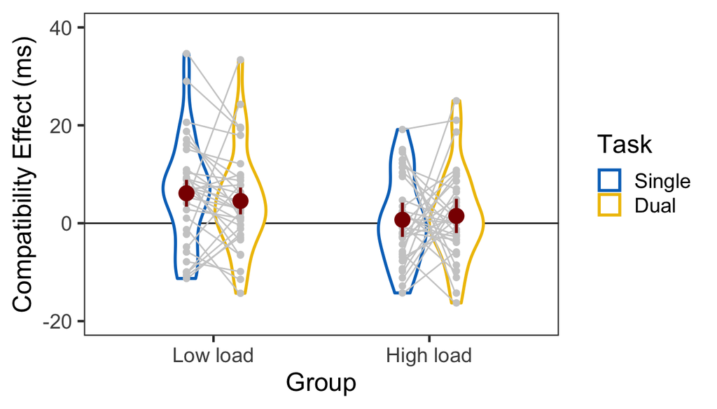

```r
ggplot(data=tTTCEslong, aes(x=group, y=value, color=task)) +
  geom_hline(yintercept = 0) +
  geom_violin(width = 0.5, size=1, trim=TRUE) +
  geom_point(aes(x=group, y=value, group=task),
             position=position_dodge(0.5), color="gray80", size=1.8, show.legend = FALSE) +
  geom_segment(data=filter(tTTCEswide, group=="Low"), inherit.aes = FALSE,
               aes(x=1-.12, y=filter(tTTCEswide, group=="Low")$absCE,
                   xend=1+.12, yend=filter(tTTCEswide, group=="Low")$preCE),
               color="gray80") +
  geom_segment(data=filter(tTTCEswide, group=="High"), inherit.aes = FALSE,
               aes(x=2-.12, y=filter(tTTCEswide, group=="High")$absCE,
                   xend=2+.12, yend=filter(tTTCEswide, group=="High")$preCE),
               color="gray80") +
  geom_pointrange(data=tTTCEg,
                  aes(x = group, ymin = value-wsci, ymax = value+wsci, group = task),
                  position = position_dodge(0.5), color = "darkred", size = 1, show.legend = FALSE) +
  scale_color_manual(values=c('#0073C2FF','#EFC000FF'),
                    labels=c("Single", "Dual")) +
  scale_x_discrete(labels=c("Low" = "Low load", "High" = "High load")) +
  labs(x = "Group",
       y = "Compatibility Effect (ms)",
       color='Task') +
  coord_cartesian(ylim = c(-20, 40), clip = "on") +
  theme_bw(base_size = 18) +
  theme(panel.grid.major = element_blank(),
        panel.grid.minor = element_blank())
```

### 3.2.3 Accuracy Results

#### 3.2.3.1 Noramlity Test

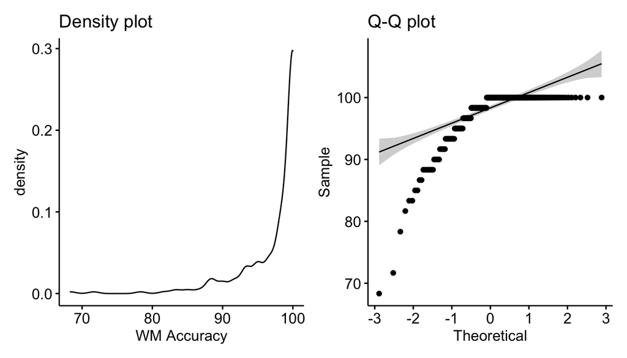

```r
N7 <- ggpubr::ggdensity(aTTslong$Accuracy,
                        main = "Density plot",
                        xlab = "WM Accuracy")
N8 <- ggpubr::ggqqplot(aTTslong$Accuracy,
                       main = "Q-Q plot")
N7 + N8 + plot_layout(nrow = 1, widths = c(1, 1))
```

```r
shapiro.test(aTTslong$Accuracy)  # 가정 위배
```

```
    Shapiro-Wilk normality test

data:  aTTslong$Accuracy
W = 0.64282, p-value < 2.2e-16
```

자료가 정규성 가정에 위배된다.

#### 3.2.3.2 Permutation Test

```r
aTT.perm <- aovperm(Accuracy ~ group * task * compatibility + Error(sid/(task*compatibility)),
                    data = aTTslong, np = nsims)
summary(aTT.perm) %>%
    kable(digits = 4, caption = "Nonparametric ANOVA")
```

Nonparametric ANOVA

|  | SSn | dfn | SSd | dfd | MSEn | MSEd | F | parametric P(>F) | resampled P(>F) |
| --- | --- | --- | --- | --- | --- | --- | --- | --- | --- |
| group | 11.1111 | 1 | 4641.4931 | 62 | 11.1111 | 74.8628 | 0.1484 | 0.7014 | 0.7083 |
| task | 0.3906 | 1 | 391.5799 | 62 | 0.3906 | 6.3158 | 0.0618 | 0.8044 | 0.8041 |
| group:task | 5.2517 | 1 | 391.5799 | 62 | 5.2517 | 6.3158 | 0.8315 | 0.3654 | 0.3638 |
| compatibility | 17.3611 | 1 | 234.7222 | 62 | 17.3611 | 3.7858 | 4.5858 | 0.0362 | 0.0344 |
| group:compatibility | 0.6944 | 1 | 234.7222 | 62 | 0.6944 | 3.7858 | 0.1834 | 0.6699 | 0.6731 |
| task:compatibility | 3.5156 | 1 | 241.9271 | 62 | 3.5156 | 3.9020 | 0.9010 | 0.3462 | 0.3559 |
| group:task:compatibility | 15.6684 | 1 | 241.9271 | 62 | 15.6684 | 3.9020 | 4.0154 | 0.0495 | 0.0525 |

`compatibility` 주효과만 유의미하였다. `group:load:cong` 상호작용이 유의미한 경향성을 보였다.

```r
aTTLS.perm <- aovperm(Accuracy ~ compatibility + Error(sid/(compatibility)),
                      data = filter(aTTslong, group=='Low', task=='Single'), np = nsims)
summary(aTTLS.perm) %>%
    kable(digits = 4, caption = "Low load & Single task: Simon effect")
```

Low load & Single task: Simon effect

|  | SSn | dfn | SSd | dfd | MSEn | MSEd | F | parametric P(>F) | resampled P(>F) |
| --- | --- | --- | --- | --- | --- | --- | --- | --- | --- |
| compatibility | 2.1267 | 1 | 143.7066 | 31 | 2.1267 | 4.6357 | 0.4588 | 0.5032 | 0.5197 |

```r
aTTLD.perm <- aovperm(Accuracy ~ compatibility + Error(sid/(compatibility)),
                      data = filter(aTTslong, group=='Low', task=='Dual'), np = nsims)
summary(aTTLD.perm) %>%
    kable(digits = 4, caption = "Low load & Dual task: Simon effect")
```

Low load & Dual task: Simon effect

|  | SSn | dfn | SSd | dfd | MSEn | MSEd | F | parametric P(>F) | resampled P(>F) |
| --- | --- | --- | --- | --- | --- | --- | --- | --- | --- |
| compatibility | 12.5434 | 1 | 105.5122 | 31 | 12.5434 | 3.4036 | 3.6853 | 0.0641 | 0.0681 |

```r
aTTHS.perm <- aovperm(Accuracy ~ compatibility + Error(sid/(compatibility)),
                      data = filter(aTTslong, group=='High', task=='Single'), np = nsims)
summary(aTTHS.perm) %>%
    kable(digits = 4, caption = "High load & Single task: Simon effect")
```

High load & Single task: Simon effect

|  | SSn | dfn | SSd | dfd | MSEn | MSEd | F | parametric P(>F) | resampled P(>F) |
| --- | --- | --- | --- | --- | --- | --- | --- | --- | --- |
| compatibility | 21.0069 | 1 | 81.7708 | 31 | 21.0069 | 2.6378 | 7.9639 | 0.0083 | 0.0068 |

```r
aTTHD.perm <- aovperm(Accuracy ~ compatibility + Error(sid/(compatibility)),
                      data = filter(aTTslong, group=='High', task=='Dual'), np = nsims)
summary(aTTHD.perm) %>%
    kable(digits = 4, caption = "High load & Dual task: Simon effect")
```

High load & Dual task: Simon effect

|  | SSn | dfn | SSd | dfd | MSEn | MSEd | F | parametric P(>F) | resampled P(>F) |
| --- | --- | --- | --- | --- | --- | --- | --- | --- | --- |
| compatibility | 1.5625 | 1 | 145.6597 | 31 | 1.5625 | 4.6987 | 0.3325 | 0.5683 | 0.5707 |

사후검증에서 FDR 절차로 *p*-value를 보정하였다.

```r
tmp <- p.adjust(c(aTTLS.perm$table$`resampled P(>F)`,
                  aTTLD.perm$table$`resampled P(>F)`,
                  aTTHS.perm$table$`resampled P(>F)`,
                  aTTHD.perm$table$`resampled P(>F)`), "fdr")
data.frame(LowloadSolo = tmp[1], LowloadDual = tmp[2],
           HighloadSolo = tmp[3], HighloadDual = tmp[4]) %>%
  kable(align = 'c', digits = 4, caption = "FDR adjusted p-values")
```

FDR adjusted p-values

| LowloadSolo | LowloadDual | HighloadSolo | HighloadDual |
| --- | --- | --- | --- |
| 0.5707 | 0.1362 | 0.0272 | 0.5707 |

#### 3.2.3.3 Power Test

```r
daT <- ANOVA_design(
    design = "2b*2w*2w",
    n = 32,
    mu = aTTsum$MN,
    sd = aTTsum$SD,
    labelnames = c("G", "Lo", "Hi",
                                 "T", "Sing", "Dual",
                                 "C", "Cmp", "Inc"),
    plot = FALSE
)

daTpwr <- ANOVA_power(daT, verbose = FALSE, nsims = nsims)

daTpwr$main_results %>%
    kable(digits = 4, caption = "Effect Sizes: ANOVA")
```

Effect Sizes: ANOVA

|  | power | effect_size |
| --- | --- | --- |
| anova_G | 10.22 | 0.0231 |
| anova_T | 5.11 | 0.0161 |
| anova_G:T | 7.85 | 0.0196 |
| anova_C | 14.48 | 0.0279 |
| anova_G:C | 5.08 | 0.0162 |
| anova_T:C | 7.16 | 0.0184 |
| anova_G:T:C | 13.56 | 0.0266 |

```r
daTpwr$pc_results[c(1,14,23,28),] %>%
    kable(digits = 4, caption = "Effect Sizes: Post-hoc")
```

Effect Sizes: Post-hoc

|  | power | effect_size |
| --- | --- | --- |
| p_G_Lo_T_Sing_C_Cmp_G_Lo_T_Sing_C_Inc | 5.94 | -0.0758 |
| p_G_Lo_T_Dual_C_Cmp_G_Lo_T_Dual_C_Inc | 12.38 | -0.2083 |
| p_G_Hi_T_Sing_C_Cmp_G_Hi_T_Sing_C_Inc | 21.89 | -0.3043 |
| p_G_Hi_T_Dual_C_Cmp_G_Hi_T_Dual_C_Inc | 5.80 | 0.0555 |

### 3.2.4 RT Results

#### 3.2.4.1 Normality Test

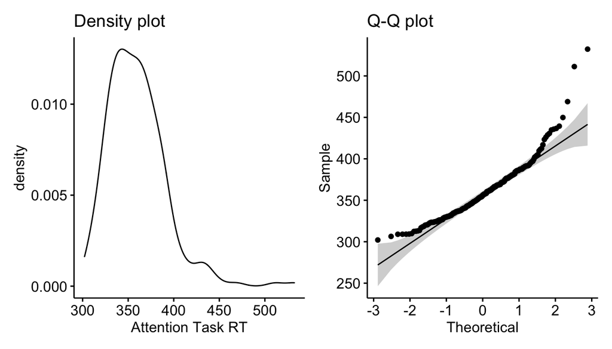

```r
N9 <- ggpubr::ggdensity(tTTslong$RT,
                        main = "Density plot",
                        xlab = "Attention Task RT")
N10 <- ggpubr::ggqqplot(tTTslong$RT,
                       main = "Q-Q plot")
N9 + N10 + plot_layout(nrow = 1, widths = c(1, 1))
```

```r
shapiro.test(tTTslong$RT) # 가정 위배
```

```
    Shapiro-Wilk normality test

data:  tTTslong$RT
W = 0.91493, p-value = 6.715e-11
```

반응시간 자료도 정규성 가정에 위배되었다.

#### 3.2.4.2 Permutation Test

```r
tTT.perm <- aovperm(RT ~ group * task * compatibility + Error(sid/(task*compatibility)),
                    data = tTTslong, np = nsims)
summary(tTT.perm) %>%
    kable(digits = 4, caption = "Nonparametric ANOVA")
```

Nonparametric ANOVA

|  | SSn | dfn | SSd | dfd | MSEn | MSEd | F | parametric P(>F) | resampled P(>F) |
| --- | --- | --- | --- | --- | --- | --- | --- | --- | --- |
| group | 1102.8047 | 1 | 245617.772 | 62 | 1102.8047 | 3961.5770 | 0.2784 | 0.5997 | 0.6060 |
| task | 1824.0043 | 1 | 9822.264 | 62 | 1824.0043 | 158.4236 | 11.5135 | 0.0012 | 0.0010 |
| group:task | 2.6397 | 1 | 9822.264 | 62 | 2.6397 | 158.4236 | 0.0167 | 0.8977 | 0.9028 |
| compatibility | 663.0186 | 1 | 3790.207 | 62 | 663.0186 | 61.1324 | 10.8456 | 0.0016 | 0.0018 |
| group:compatibility | 287.3328 | 1 | 3790.207 | 62 | 287.3328 | 61.1324 | 4.7002 | 0.0340 | 0.0328 |
| task:compatibility | 2.4994 | 1 | 2356.338 | 62 | 2.4994 | 38.0055 | 0.0658 | 0.7985 | 0.7973 |
| group:task:compatibility | 22.0592 | 1 | 2356.338 | 62 | 22.0592 | 38.0055 | 0.5804 | 0.4490 | 0.4545 |

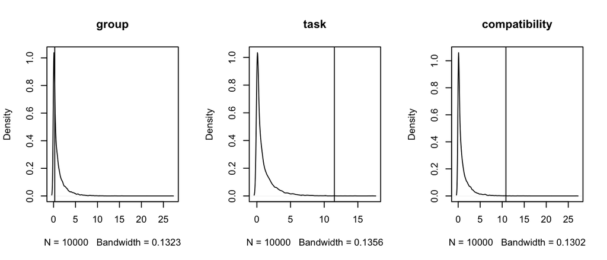

```r
plot(tTT.perm, effect = c("group", "task", "compatibility"))
```

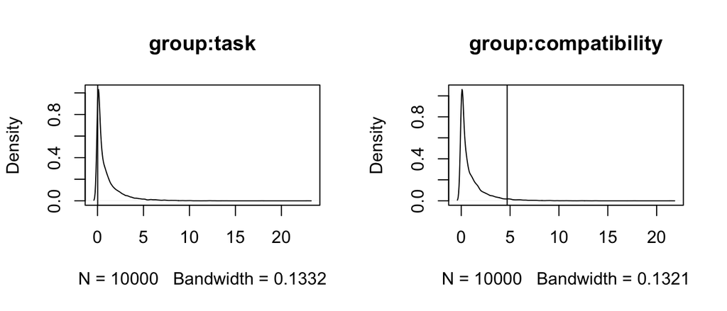

```r
plot(tTT.perm, effect = c("group:task", "group:compatibility"))
```

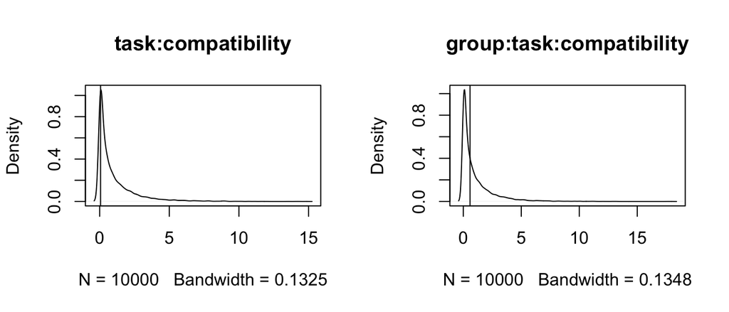

```r
plot(tTT.perm, effect = c("task:compatibility", "group:task:compatibility") )
```

조건별 일치효과가 0보다 큰지 확인하였다.

```r
tTTLS.perm <- aovperm(RT ~ compatibility + Error(sid/(compatibility)),
                      data = filter(tTTslong, group=='Low', task=='Single'), np = nsims)
summary(tTTLS.perm) %>%
    kable(digits = 4, caption = "Low load & Single task: Simon effect")
```

Low load & Single task: Simon effect

|  | SSn | dfn | SSd | dfd | MSEn | MSEd | F | parametric P(>F) | resampled P(>F) |
| --- | --- | --- | --- | --- | --- | --- | --- | --- | --- |
| compatibility | 599.7039 | 1 | 1903.501 | 31 | 599.7039 | 61.4033 | 9.7666 | 0.0038 | 0.0043 |

```r
tTTLD.perm <- aovperm(RT ~ compatibility + Error(sid/(compatibility)),
                      data = filter(tTTslong, group=='Low', task=='Dual'), np = nsims)
summary(tTTLD.perm) %>%
    kable(digits = 4, caption = "Low load & Dual task: Simon effect")
```

Low load & Dual task: Simon effect

|  | SSn | dfn | SSd | dfd | MSEn | MSEd | F | parametric P(>F) | resampled P(>F) |
| --- | --- | --- | --- | --- | --- | --- | --- | --- | --- |
| compatibility | 331.6474 | 1 | 1670.003 | 31 | 331.6474 | 53.8711 | 6.1563 | 0.0187 | 0.0209 |

```r
tTTHS.perm <- aovperm(RT ~ compatibility + Error(sid/(compatibility)),
                      data = filter(tTTslong, group=='High', task=='Single'), np = nsims)
summary(tTTHS.perm) %>%
    kable(digits = 4, caption = "High load & Single task: Simon effect")
```

High load & Single task: Simon effect

|  | SSn | dfn | SSd | dfd | MSEn | MSEd | F | parametric P(>F) | resampled P(>F) |
| --- | --- | --- | --- | --- | --- | --- | --- | --- | --- |
| compatibility | 8.0726 | 1 | 1191.88 | 31 | 8.0726 | 38.4478 | 0.21 | 0.65 | 0.6449 |

```r
tTTHD.perm <- aovperm(RT ~ compatibility + Error(sid/(compatibility)),
                      data = filter(tTTslong, group=='High', task=='Dual'), np = nsims)
summary(tTTHD.perm) %>%
    kable(digits = 4, caption = "High load & Dual task: Simon effect")
```

High load & Dual task: Simon effect

|  | SSn | dfn | SSd | dfd | MSEn | MSEd | F | parametric P(>F) | resampled P(>F) |
| --- | --- | --- | --- | --- | --- | --- | --- | --- | --- |
| compatibility | 35.486 | 1 | 1381.161 | 31 | 35.486 | 44.5536 | 0.7965 | 0.379 | 0.392 |

사후검증에서 FDR 절차로 *p*-value를 보정하였다.

```r
tmp <- p.adjust(c(tTTLS.perm$table$`resampled P(>F)`,
                  tTTLD.perm$table$`resampled P(>F)`,
                  tTTHS.perm$table$`resampled P(>F)`,
                  tTTHD.perm$table$`resampled P(>F)`), "fdr")
data.frame(LowloadSolo = tmp[1], LowloadDual = tmp[2],
           HighloadSolo = tmp[3], HighloadDual = tmp[4]) %>%
  kable(align = 'c', digits = 4, caption = "FDR adjusted p-values")
```

FDR adjusted p-values

| LowloadSolo | LowloadDual | HighloadSolo | HighloadDual |
| --- | --- | --- | --- |
| 0.0172 | 0.0418 | 0.6449 | 0.5227 |

#### 3.2.4.3 Power Test

```r
drT <- ANOVA_design(
    design = "2b*2w*2w",
    n = 32,
    mu = tTTsum$MN,
    sd = tTTsum$SD,
    labelnames = c("G", "Lo", "Hi",
                                 "T", "Sing", "Dual",
                                 "C", "Cmp", "Inc"),
    plot = FALSE
)

drTpwr <- ANOVA_power(drT, verbose = FALSE, nsims = nsims)

drTpwr$main_results %>%
    kable(digits = 4, caption = "Effect Sizes: ANOVA")
```

Effect Sizes: ANOVA

|  | power | effect_size |
| --- | --- | --- |
| anova_G | 17.79 | 0.0319 |
| anova_T | 25.18 | 0.0412 |
| anova_G:T | 4.98 | 0.0160 |
| anova_C | 12.46 | 0.0255 |
| anova_G:C | 8.71 | 0.0204 |
| anova_T:C | 5.02 | 0.0159 |
| anova_G:T:C | 4.84 | 0.0160 |

```r
drTpwr$pc_results[c(1,14,23,28),] %>%
    kable(digits = 4, caption = "Effect Sizes: Post-hoc")
```

Effect Sizes: Post-hoc

|  | power | effect_size |
| --- | --- | --- |
| p_G_Lo_T_Sing_C_Cmp_G_Lo_T_Sing_C_Inc | 14.06 | 0.2231 |
| p_G_Lo_T_Dual_C_Cmp_G_Lo_T_Dual_C_Inc | 10.61 | 0.1719 |
| p_G_Hi_T_Sing_C_Cmp_G_Hi_T_Sing_C_Inc | 5.17 | 0.0225 |
| p_G_Hi_T_Dual_C_Cmp_G_Hi_T_Dual_C_Inc | 5.41 | 0.0364 |

# 4 Plots

## 4.1 Experiment 1

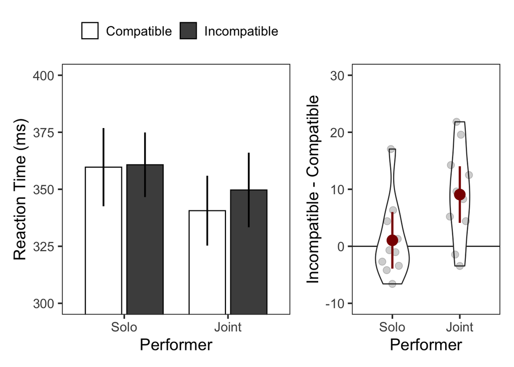

```r
G3 <- ggplot() +
  geom_bar(data=cS1g, aes(x=performer, y=rt, fill=compatibility),
           stat="identity", width=0.7, color="black", position=position_dodge(.8)) +
  geom_linerange(data=cS1g, aes(x=performer, ymin=rt-wsci, ymax=rt+wsci, group=compatibility),
                 size=0.8, position=position_dodge(0.8)) +
  scale_fill_manual(values=c('gray100','gray30'),
                    labels=c("Compatible", "Incompatible")) +
  labs(x = "Performer", y = "Reaction Time (ms)") +
  coord_cartesian(ylim = c(300, 400), clip = "on") +
  theme_bw(base_size = 16) +
  theme(legend.position="top",
        legend.spacing.x = unit(0.5, 'lines'),
        legend.title = element_blank(),
        legend.background = element_blank(),
        panel.grid.major = element_blank(),
        panel.grid.minor = element_blank())

G4 <- ggplot(cS1CEslong, aes(x=performer, y=ce)) +
  geom_hline(yintercept = 0) +
  geom_violin(width = 0.5, trim=TRUE) +
  ggbeeswarm::geom_quasirandom(color = "black", size = 3, alpha = 0.2, width = 0.2) +
  geom_pointrange(cS1CEg, inherit.aes=FALSE,
                  mapping=aes(x = performer, y=ce,
                              ymin = ce - wsci, ymax = ce + wsci),
                  colour="darkred", size = 1) +
  labs(x = "Performer", y = "Incompatible - Compatible") +
  coord_cartesian(ylim = c(-10, 30), clip = "on") +
  scale_y_continuous(breaks=c(-10, 0, 10, 20, 30)) +
  theme_bw(base_size = 16) +
  theme(panel.grid.major = element_blank(),
        panel.grid.minor = element_blank())

# Multipanel plot
G3 + G4 + plot_layout(nrow = 1, widths = c(2, 1.3))
```

## 4.2 Experiment 2

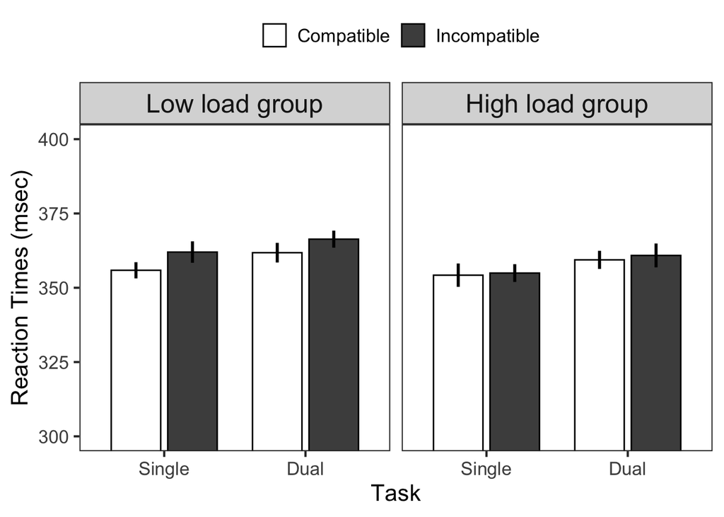

```r
ggplot() +
  geom_bar(data=tTTg, aes(x=task, y=RT, fill=compatibility),
           stat="identity", width=0.7, color="black", position=position_dodge(.8)) +
  facet_wrap(~group, labeller = labeller(group = group.labs)) +
  geom_linerange(data=tTTg, aes(x=task, ymin=RT-wsci, ymax=RT+wsci, group=compatibility),
                 size=1, position=position_dodge(0.8)) +
  scale_fill_manual(values=c('gray100','gray30'),
                    labels=c("Compatible", "Incompatible")) +
  labs(x = "Task", y = "Reaction Times (msec)") +
  coord_cartesian(ylim = c(300, 400), clip = "on") +
  theme_bw(base_size = 16) +
  theme(legend.position="top",
        legend.spacing.x = unit(0.5, 'lines'),
        strip.text.x = element_text(size = 18),
        legend.title = element_blank(),
        legend.background = element_blank(),
        panel.grid.major = element_blank(),
        panel.grid.minor = element_blank())
```

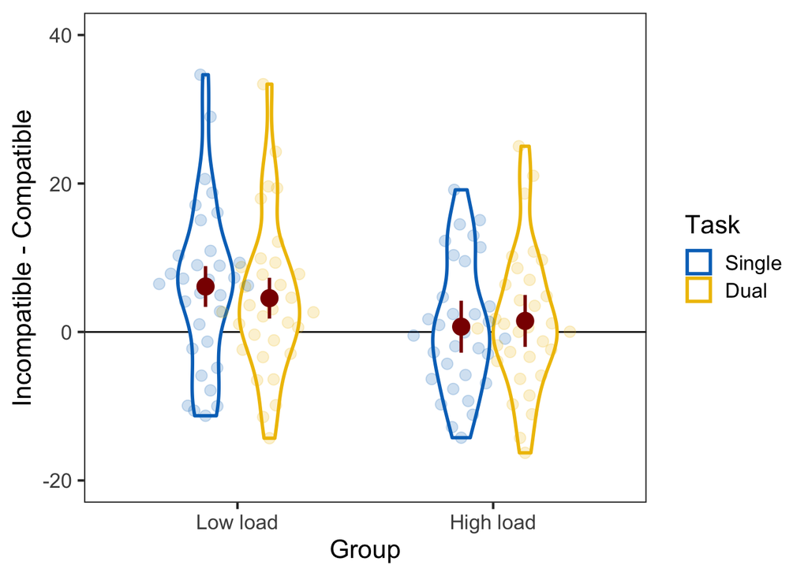

```r
ggplot(data=tTTCEslong, aes(x=group, y=value, color=task)) +
  geom_hline(yintercept = 0) +
  geom_violin(width = 0.5, size=1, trim=TRUE) +
  ggbeeswarm::geom_quasirandom(groupOnX = TRUE, dodge.width=.5,
                               size = 3, alpha = 0.2, width = 0.2,
                               show.legend = FALSE) +
  geom_pointrange(data=tTTCEg,
                  aes(x = group, ymin = value-wsci, ymax = value+wsci, group = task),
                  position = position_dodge(0.5), color = "darkred", size = 1, show.legend = FALSE) +
  scale_color_manual(values=c('#0073C2FF','#EFC000FF'),
                     labels=c("Single", "Dual")) +
  scale_x_discrete(labels=c("Low" = "Low load", "High" = "High load")) +
  labs(x = "Group",
       y = "Incompatible - Compatible",
       color='Task') +
  coord_cartesian(ylim = c(-20, 40), clip = "on") +
  theme_bw(base_size = 16) +
  theme(panel.grid.major = element_blank(),
        panel.grid.minor = element_blank())
```

# 5 Session Info

```r
sessionInfo()
## R version 4.1.3 (2022-03-10)
## Platform: x86_64-apple-darwin17.0 (64-bit)
## Running under: macOS Big Sur/Monterey 10.16
##
## Matrix products: default
## BLAS:   /Library/Frameworks/R.framework/Versions/4.1/Resources/lib/libRblas.0.dylib
## LAPACK: /Library/Frameworks/R.framework/Versions/4.1/Resources/lib/libRlapack.dylib
##
## locale:
## [1] en_US.UTF-8/en_US.UTF-8/en_US.UTF-8/C/en_US.UTF-8/en_US.UTF-8
##
## attached base packages:
## [1] stats     graphics  grDevices utils     datasets  methods   base
##
## other attached packages:
##  [1] Superpower_0.1.2  permuco_1.1.1     patchwork_1.1.1   cowplot_1.1.1
##  [5] emmeans_1.7.3     afex_1.1-0        lme4_1.1-29       Matrix_1.4-1
##  [9] knitr_1.38        papaja_0.1.0.9997 psych_2.2.3       forcats_0.5.1
## [13] stringr_1.4.0     dplyr_1.0.8       purrr_0.3.4       readr_2.1.2
## [17] tidyr_1.2.0       tibble_3.1.6      ggplot2_3.3.5     tidyverse_1.3.1
## [21] pacman_0.5.1
##
## loaded via a namespace (and not attached):
##   [1] ggbeeswarm_0.6.0    TH.data_1.1-0       minqa_1.2.4
##   [4] colorspace_2.0-3    ggsignif_0.6.3      ellipsis_0.3.2
##   [7] htmlTable_2.4.0     estimability_1.3    base64enc_0.1-3
##  [10] fs_1.5.2            rstudioapi_0.13     ggpubr_0.4.0
##  [13] farver_2.1.0        fansi_1.0.3         mvtnorm_1.1-3
##  [16] lubridate_1.8.0     xml2_1.3.3          codetools_0.2-18
##  [19] splines_4.1.3       mnormt_2.0.2        Formula_1.2-4
##  [22] jsonlite_1.8.0      nloptr_2.0.0        broom_0.8.0
##  [25] cluster_2.1.3       dbplyr_2.1.1        png_0.1-7
##  [28] compiler_4.1.3      httr_1.4.2          backports_1.4.1
##  [31] assertthat_0.2.1    fastmap_1.1.0       cli_3.2.0
##  [34] htmltools_0.5.2     tools_4.1.3         lmerTest_3.1-3
##  [37] coda_0.19-4         gtable_0.3.0        glue_1.6.2
##  [40] reshape2_1.4.4      Rcpp_1.0.8.3        carData_3.0-5
##  [43] cellranger_1.1.0    jquerylib_0.1.4     vctrs_0.4.1
##  [46] nlme_3.1-157        xfun_0.30           rvest_1.0.2
##  [49] lifecycle_1.0.1     rstatix_0.7.0       MASS_7.3-56
##  [52] zoo_1.8-9           scales_1.2.0        hms_1.1.1
##  [55] parallel_4.1.3      sandwich_3.0-1      RColorBrewer_1.1-3
##  [58] yaml_2.3.5          gridExtra_2.3       sass_0.4.1
##  [61] rpart_4.1.16        latticeExtra_0.6-29 stringi_1.7.6
##  [64] highr_0.9           checkmate_2.0.0     permute_0.9-7
##  [67] boot_1.3-28         rlang_1.0.2         pkgconfig_2.0.3
##  [70] evaluate_0.15       lattice_0.20-45     labeling_0.4.2
##  [73] htmlwidgets_1.5.4   tidyselect_1.1.2    plyr_1.8.7
##  [76] magrittr_2.0.3      R6_2.5.1            magick_2.7.3
##  [79] generics_0.1.2      Hmisc_4.6-0         multcomp_1.4-18
##  [82] DBI_1.1.2           foreign_0.8-82      pillar_1.7.0
##  [85] haven_2.4.3         withr_2.5.0         nnet_7.3-17
##  [88] survival_3.3-1      abind_1.4-5         modelr_0.1.8
##  [91] crayon_1.5.1        car_3.0-12          utf8_1.2.2
##  [94] tmvnsim_1.0-2       tzdb_0.3.0          rmarkdown_2.13
##  [97] jpeg_0.1-9          grid_4.1.3          readxl_1.4.0
## [100] data.table_1.14.2   reprex_2.0.1        digest_0.6.29
## [103] xtable_1.8-4        numDeriv_2016.8-1.1 munsell_0.5.0
## [106] beeswarm_0.4.0      vipor_0.4.5         bslib_0.3.1
```